# **Deep Learning Project: Street View Housing Number Digit Recognition**

# **Marks: 60**

## **Context**

One of the most interesting tasks in deep learning is to recognize objects in natural scenes. The ability to process visual information using machine learning algorithms can be very useful as demonstrated in various applications.

The SVHN dataset contains over 600,000 labeled digits cropped from street-level photos. It is one of the most popular image recognition datasets. It has been used in neural networks created by Google to improve the map quality by automatically transcribing the address numbers from a patch of pixels. The transcribed number with a known street address helps pinpoint the location of the building it represents.

## **Objective**

Our objective is to predict the number depicted inside the image by using Artificial or Fully Connected Feed Forward Neural Networks and Convolutional Neural Networks. We will go through various models of each and finally select the one that is giving us the best performance.

## **Dataset**

Here, we will use a subset of the original data to save some computation time. The dataset is provided as a .h5 file. The basic preprocessing steps have been applied on the dataset.

## **Mount the drive**

Let us start by mounting the Google drive. You can run the below cell to mount the Google drive.

```python
# Mount google drive
from google.colab import drive
drive.mount('/content/drive')
```

## **Importing the necessary libraries**

```python
# install tensorflow
!pip install tensorflow
```

```python
#import neccessary libraries
import numpy as np

import pandas as pd

import matplotlib.pyplot as plt

import seaborn as sns

from sklearn.model_selection import train_test_split

from sklearn.preprocessing import MinMaxScaler

import tensorflow as tf

from tensorflow.keras.models import Sequential

from tensorflow.keras.layers import Dense, Dropout, Activation, BatchNormalization

from tensorflow.keras.losses import categorical_crossentropy

from tensorflow.keras.optimizers import Adam

from tensorflow.keras.utils import to_categorical
```

**Let us check the version of tensorflow.**

```python
# tensorflow version
print(tf.__version__)
```

```
2.18.0
```

## **Load the dataset**

- Let us now load the dataset that is available as a .h5 file.
- Split the data into the train and the test dataset.

```python
#import h5py
import h5py

#load .h5 data
Data = h5py.File('/content/drive/MyDrive/Colab Notebooks/MIT_DATASETS/SVHN_single_grey1.h5', 'r')

#splite Data into training and testing dataset
X_train = Data['X_train'][:]
y_train = Data['y_train'][:]
X_test = Data['X_test'][:]
y_test = Data['y_test'][:]
```

Check the number of images in the training and the testing dataset.

```python
#print the length of training and testing datasets
print("Train shape:", X_train.shape, y_train.shape)
print("Test shape:", X_test.shape, y_test.shape)
```

```
Train shape: (42000, 32, 32) (42000,)
Test shape: (18000, 32, 32) (18000,)
```

**Observations:**

- The training dataset contains 42,000 grayscale images, each of size 32x32 pixels, with corresponding labels for each image. -The test dataset contains 18,000 grayscale images, each of size 32x32 pixels, with corresponding labels. -The dataset is sufficiently large and well-split, which should help in training robust deep learning models and evaluating their performance effectively.

## **Visualizing images**

- Use X_train to visualize the first 10 images.
- Use Y_train to print the first 10 labels.

```
Labels for the above images: [2 6 7 4 4 0 3 0 7 3]
```

```python
# Visualize the first 10 images in the training dataset and print their labels
plt.figure(figsize=(10, 1))
for i in range(10):
    plt.subplot(1, 10, i + 1)
    plt.imshow(X_train[i], cmap="gray")
    plt.axis('off')
plt.show()

print("Labels for the above images:", y_train[:10])
```

[output not shown]

## **Data preparation**

- Print the shape and the array of pixels for the first image in the training dataset.
- Normalize the train and the test dataset by dividing by 255.
- Print the new shapes of the train and the test dataset.
- One-hot encode the target variable.

```python
# Print the shape and the array of pixels for the first image in the training dataset
print("Shape of the first image:", X_train[0].shape)
np.set_printoptions(precision=4, suppress=True)
print("Pixel array of the first image:\n", X_train[0])
```

```
Shape of the first image: (32, 32)
Pixel array of the first image:
 [[ 33.0704  30.2601  26.852  ...  71.4471  58.2204  42.9939]
 [ 25.2283  25.5533  29.9765 ... 113.0209 103.3639  84.2949]
 [ 26.2775  22.6137  40.4763 ... 113.3028 121.775  115.4228]
 ...
 [ 28.5502  36.212   45.0801 ...  24.1359  25.0927  26.0603]
 [ 38.4352  26.4733  23.2717 ...  28.1094  29.4683  30.0661]
 [ 50.2984  26.0773  24.0389 ...  49.6682  50.853   53.0377]]
```

### **Normalize the train and the test data**

```python
# Normalize the train and the test dataset by dividing by 255
X_train = X_train / 255.0
X_test = X_test / 255.0
```

Print the shapes of Training and Test data

```python
# Print the new shapes of the train and the test dataset
print("New shape of X_train:", X_train.shape)
print("New shape of X_test:", X_test.shape)
print("New shape of y_train:", y_train.shape)
print("New shape of y_test:", y_test.shape)
```

```
New shape of X_train: (42000, 32, 32)
New shape of X_test: (18000, 32, 32)
New shape of y_train: (42000,)
New shape of y_test: (18000,)
```

### **One-hot encode output**

```python
# One-hot encode the target variable
y_train_encoded = to_categorical(y_train, num_classes=10)
y_test_encoded = to_categorical(y_test, num_classes=10)

print("One-hot encoded y_train (first 10 labels):\n", y_train_encoded[:10])
print("One-hot encoded y_test (first 10 labels):\n", y_test_encoded[:10])
```

```
One-hot encoded y_train (first 10 labels):
 [[0. 0. 1. 0. 0. 0. 0. 0. 0. 0.]
 [0. 0. 0. 0. 0. 0. 1. 0. 0. 0.]
 [0. 0. 0. 0. 0. 0. 0. 1. 0. 0.]
 [0. 0. 0. 0. 1. 0. 0. 0. 0. 0.]
 [0. 0. 0. 0. 1. 0. 0. 0. 0. 0.]
 [1. 0. 0. 0. 0. 0. 0. 0. 0. 0.]
 [0. 0. 0. 1. 0. 0. 0. 0. 0. 0.]
 [1. 0. 0. 0. 0. 0. 0. 0. 0. 0.]
 [0. 0. 0. 0. 0. 0. 0. 1. 0. 0.]
 [0. 0. 0. 1. 0. 0. 0. 0. 0. 0.]]
One-hot encoded y_test (first 10 labels):
 [[0. 1. 0. 0. 0. 0. 0. 0. 0. 0.]
 [0. 0. 0. 0. 0. 0. 0. 1. 0. 0.]
 [0. 0. 1. 0. 0. 0. 0. 0. 0. 0.]
 [0. 0. 0. 0. 0. 0. 0. 0. 0. 1.]
 [1. 0. 0. 0. 0. 0. 0. 0. 0. 0.]
 [0. 0. 0. 0. 0. 0. 0. 0. 0. 1.]
 [0. 1. 0. 0. 0. 0. 0. 0. 0. 0.]
 [0. 0. 0. 0. 0. 0. 0. 0. 1. 0.]
 [0. 0. 0. 0. 1. 0. 0. 0. 0. 0.]
 [0. 0. 0. 0. 1. 0. 0. 0. 0. 0.]]
```

**Observation:**

- Both y_train and y_test are one-hot encoded label arrays, each with 10 columns, indicating a 10-class classification.
- Each row contains a single 1.0 and the rest are 0.0, representing the class label for that sample.
- The distribution of classes appears to be varied in both training and test sets, suggesting that the data is not ordered by class and likely shuffled.
- The one-hot encoding format is suitable for use with neural networks or other models that require categorical labels in this format.

## **Model Building**

Now that we have done the data preprocessing, let's build an ANN model.

### Fix the seed for random number generators

```python
#Fix the seed for random number generator
import random
seed_value = 42
np.random.seed(seed_value)
tf.random.set_seed(seed_value)
random.seed(seed_value)
```

### **Model Architecture**

- Write a function that returns a sequential model with the following architecture:
- First hidden layer with **64 nodes and the relu activation** and the **input shape = (1024, )**
- Second hidden layer with **32 nodes and the relu activation**
- Output layer with **activation as 'softmax' and number of nodes equal to the number of classes, i.e., 10**
- Compile the model with the **loss equal to categorical_crossentropy, optimizer equal to Adam(learning_rate = 0.001), and metric equal to 'accuracy'**. Do not fit the model here, just return the compiled model.
- Call the nn_model_1 function and store the model in a new variable.
- Print the summary of the model.
- Fit on the train data with a **validation split of 0.2, batch size = 128, verbose = 1, and epochs = 20**. Store the model building history to use later for visualization.

### **Build and train an ANN model as per the above mentioned architecture.**

```python
# Function to build the ANN model
def nn_model_1():
    model = Sequential()
    model.add(Dense(64, activation='relu', input_shape=(1024,)))
    model.add(Dense(32, activation='relu'))
    model.add(Dense(10, activation='softmax'))
    model.compile(
        loss='categorical_crossentropy',
        optimizer=Adam(learning_rate=0.001),
        metrics=['accuracy']
    )
    return model

# Flatten the images for ANN input
X_train_flat = X_train.reshape(X_train.shape[0], -1)
X_test_flat = X_test.reshape(X_test.shape[0], -1)

# Build and summarize the model
model1 = nn_model_1()
model1.summary()

# Fit the model
history1 = model1.fit(
    X_train_flat, y_train_encoded,
    validation_split=0.2,
    batch_size=128,
    epochs=20,
    verbose=1
)
```

```
Model: "sequential"
```

```
┏━━━━━━━━━━━━━━━━━━━━━━━━━━━━━━━━━┳━━━━━━━━━━━━━━━━━━━━━━━━┳━━━━━━━━━━━━━━━┓
┃ Layer (type)                    ┃ Output Shape           ┃       Param # ┃
┡━━━━━━━━━━━━━━━━━━━━━━━━━━━━━━━━━╇━━━━━━━━━━━━━━━━━━━━━━━━╇━━━━━━━━━━━━━━━┩
│ dense (Dense)                   │ (None, 64)             │        65,600 │
├─────────────────────────────────┼────────────────────────┼───────────────┤
│ dense_1 (Dense)                 │ (None, 32)             │         2,080 │
├─────────────────────────────────┼────────────────────────┼───────────────┤
│ dense_2 (Dense)                 │ (None, 10)             │           330 │
└─────────────────────────────────┴────────────────────────┴───────────────┘
```

```
 Total params: 68,010 (265.66 KB)
```

```
 Trainable params: 68,010 (265.66 KB)
```

```
 Non-trainable params: 0 (0.00 B)
```

```
263/263 ━━━━━━━━━━━━━━━━━━━━ 3s 6ms/step - accuracy: 0.1088 - loss: 2.3082 - val_accuracy: 0.1744 - val_loss: 2.2324
263/263 ━━━━━━━━━━━━━━━━━━━━ 2s 5ms/step - accuracy: 0.2135 - loss: 2.1556 - val_accuracy: 0.3065 - val_loss: 1.9384
263/263 ━━━━━━━━━━━━━━━━━━━━ 1s 5ms/step - accuracy: 0.3158 - loss: 1.9163 - val_accuracy: 0.3844 - val_loss: 1.7683
263/263 ━━━━━━━━━━━━━━━━━━━━ 1s 5ms/step - accuracy: 0.4275 - loss: 1.6879 - val_accuracy: 0.5104 - val_loss: 1.4989
263/263 ━━━━━━━━━━━━━━━━━━━━ 1s 5ms/step - accuracy: 0.5228 - loss: 1.4552 - val_accuracy: 0.5558 - val_loss: 1.3696
263/263 ━━━━━━━━━━━━━━━━━━━━ 2s 8ms/step - accuracy: 0.5636 - loss: 1.3518 - val_accuracy: 0.5798 - val_loss: 1.3064
263/263 ━━━━━━━━━━━━━━━━━━━━ 2s 7ms/step - accuracy: 0.5877 - loss: 1.2884 - val_accuracy: 0.6018 - val_loss: 1.2553
263/263 ━━━━━━━━━━━━━━━━━━━━ 2s 5ms/step - accuracy: 0.6060 - loss: 1.2421 - val_accuracy: 0.6240 - val_loss: 1.2093
263/263 ━━━━━━━━━━━━━━━━━━━━ 3s 5ms/step - accuracy: 0.6214 - loss: 1.2007 - val_accuracy: 0.6358 - val_loss: 1.1693
263/263 ━━━━━━━━━━━━━━━━━━━━ 1s 5ms/step - accuracy: 0.6338 - loss: 1.1637 - val_accuracy: 0.6456 - val_loss: 1.1404
263/263 ━━━━━━━━━━━━━━━━━━━━ 1s 5ms/step - accuracy: 0.6456 - loss: 1.1329 - val_accuracy: 0.6550 - val_loss: 1.1145
263/263 ━━━━━━━━━━━━━━━━━━━━ 1s 5ms/step - accuracy: 0.6510 - loss: 1.1100 - val_accuracy: 0.6613 - val_loss: 1.0995
263/263 ━━━━━━━━━━━━━━━━━━━━ 2s 6ms/step - accuracy: 0.6590 - loss: 1.0912 - val_accuracy: 0.6676 - val_loss: 1.0836
263/263 ━━━━━━━━━━━━━━━━━━━━ 3s 7ms/step - accuracy: 0.6660 - loss: 1.0768 - val_accuracy: 0.6700 - val_loss: 1.0726
263/263 ━━━━━━━━━━━━━━━━━━━━ 1s 4ms/step - accuracy: 0.6707 - loss: 1.0642 - val_accuracy: 0.6717 - val_loss: 1.0653
263/263 ━━━━━━━━━━━━━━━━━━━━ 1s 5ms/step - accuracy: 0.6745 - loss: 1.0540 - val_accuracy: 0.6736 - val_loss: 1.0587
263/263 ━━━━━━━━━━━━━━━━━━━━ 1s 4ms/step - accuracy: 0.6780 - loss: 1.0428 - val_accuracy: 0.6775 - val_loss: 1.0512
263/263 ━━━━━━━━━━━━━━━━━━━━ 1s 5ms/step - accuracy: 0.6817 - loss: 1.0315 - val_accuracy: 0.6831 - val_loss: 1.0417
263/263 ━━━━━━━━━━━━━━━━━━━━ 1s 5ms/step - accuracy: 0.6834 - loss: 1.0252 - val_accuracy: 0.6867 - val_loss: 1.0333
263/263 ━━━━━━━━━━━━━━━━━━━━ 3s 5ms/step - accuracy: 0.6877 - loss: 1.0135 - val_accuracy: 0.6895 - val_loss: 1.0252
```

### **Plot the Training and Validation Accuracies and write down your Observations.**

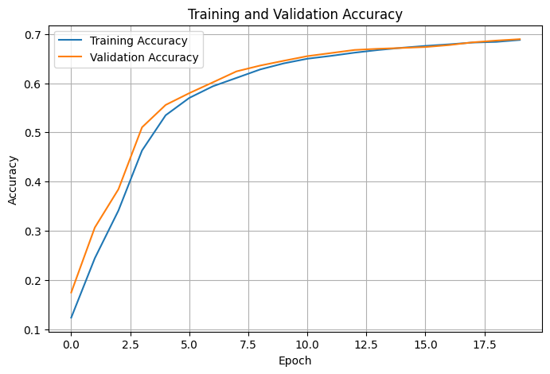

```python
# Plot the Training and Validation Accuracies
plt.figure(figsize=(8, 5))
plt.plot(history1.history['accuracy'], label='Training Accuracy')
plt.plot(history1.history['val_accuracy'], label='Validation Accuracy')
plt.title('Training and Validation Accuracy')
plt.xlabel('Epoch')
plt.ylabel('Accuracy')
plt.legend()
plt.grid(True)
plt.show()
```

**Observations:**

Let's build one more model with higher complexity and see if we can improve the performance of the model.

First, we need to clear the previous model's history from the Keras backend. Also, let's fix the seed again after clearing the backend.

```python
from tensorflow.keras import backend as K

# Clear the Keras backend session
K.clear_session()

# Fix the seed for reproducibility
seed_value = 42
np.random.seed(seed_value)
tf.random.set_seed(seed_value)
random.seed(seed_value)
```

### **Second Model Architecture**

- Write a function that returns a sequential model with the following architecture:
- First hidden layer with **256 nodes and the relu activation** and the **input shape = (1024, )**
- Second hidden layer with **128 nodes and the relu activation**
- Add the **Dropout layer with the rate equal to 0.2**
- Third hidden layer with **64 nodes and the relu activation**
- Fourth hidden layer with **64 nodes and the relu activation**
- Fifth hidden layer with **32 nodes and the relu activation**
- Add the **BatchNormalization layer**
- Output layer with **activation as 'softmax' and number of nodes equal to the number of classes, i.e., 10** -Compile the model with the **loss equal to categorical_crossentropy, optimizer equal to Adam(learning_rate = 0.0005), and metric equal to 'accuracy'**. Do not fit the model here, just return the compiled model.
- Call the nn_model_2 function and store the model in a new variable.
- Print the summary of the model.
- Fit on the train data with a **validation split of 0.2, batch size = 128, verbose = 1, and epochs = 30**. Store the model building history to use later for visualization.

### **Build and train the new ANN model as per the above mentioned architecture**

```python
# Function to build the ANN model
def nn_model_2():
    model = Sequential()
    model.add(Dense(256, activation='relu', input_shape=(1024,)))
    model.add(Dense(128, activation='relu'))
    model.add(Dropout(0.2))
    model.add(Dense(64, activation='relu'))
    model.add(Dense(64, activation='relu'))
    model.add(Dense(32, activation='relu'))
    model.add(BatchNormalization())
    model.add(Dense(10, activation='softmax'))
    model.compile(
        loss='categorical_crossentropy',
        optimizer=Adam(learning_rate=0.0005),
        metrics=['accuracy']
    )
    return model

# Flatten the images for ANN input if not already done
X_train_flat = X_train.reshape(X_train.shape[0], -1)

# Build and summarize the model
model2 = nn_model_2()
model2.summary()

# Fit the model
history2 = model2.fit(
    X_train_flat, y_train_encoded,
    validation_split=0.2,
    batch_size=128,
    epochs=30,
    verbose=1
)
```

```
Model: "sequential"
```

```
┏━━━━━━━━━━━━━━━━━━━━━━━━━━━━━━━━━┳━━━━━━━━━━━━━━━━━━━━━━━━┳━━━━━━━━━━━━━━━┓
┃ Layer (type)                    ┃ Output Shape           ┃       Param # ┃
┡━━━━━━━━━━━━━━━━━━━━━━━━━━━━━━━━━╇━━━━━━━━━━━━━━━━━━━━━━━━╇━━━━━━━━━━━━━━━┩
│ dense (Dense)                   │ (None, 256)            │       262,400 │
├─────────────────────────────────┼────────────────────────┼───────────────┤
│ dense_1 (Dense)                 │ (None, 128)            │        32,896 │
├─────────────────────────────────┼────────────────────────┼───────────────┤
│ dropout (Dropout)               │ (None, 128)            │             0 │
├─────────────────────────────────┼────────────────────────┼───────────────┤
│ dense_2 (Dense)                 │ (None, 64)             │         8,256 │
├─────────────────────────────────┼────────────────────────┼───────────────┤
│ dense_3 (Dense)                 │ (None, 64)             │         4,160 │
├─────────────────────────────────┼────────────────────────┼───────────────┤
│ dense_4 (Dense)                 │ (None, 32)             │         2,080 │
├─────────────────────────────────┼────────────────────────┼───────────────┤
│ batch_normalization             │ (None, 32)             │           128 │
│ (BatchNormalization)            │                        │               │
├─────────────────────────────────┼────────────────────────┼───────────────┤
│ dense_5 (Dense)                 │ (None, 10)             │           330 │
└─────────────────────────────────┴────────────────────────┴───────────────┘
```

```
 Total params: 310,250 (1.18 MB)
```

```
 Trainable params: 310,186 (1.18 MB)
```

```
 Non-trainable params: 64 (256.00 B)
```

```
263/263 ━━━━━━━━━━━━━━━━━━━━ 6s 13ms/step - accuracy: 0.1008 - loss: 2.4742 - val_accuracy: 0.0977 - val_loss: 2.3229
263/263 ━━━━━━━━━━━━━━━━━━━━ 5s 13ms/step - accuracy: 0.1134 - loss: 2.3043 - val_accuracy: 0.1686 - val_loss: 2.2515
263/263 ━━━━━━━━━━━━━━━━━━━━ 4s 10ms/step - accuracy: 0.2564 - loss: 2.0417 - val_accuracy: 0.4455 - val_loss: 1.6283
263/263 ━━━━━━━━━━━━━━━━━━━━ 3s 10ms/step - accuracy: 0.4879 - loss: 1.5107 - val_accuracy: 0.5455 - val_loss: 1.3410
263/263 ━━━━━━━━━━━━━━━━━━━━ 6s 13ms/step - accuracy: 0.5626 - loss: 1.3228 - val_accuracy: 0.5989 - val_loss: 1.2239
263/263 ━━━━━━━━━━━━━━━━━━━━ 4s 15ms/step - accuracy: 0.6108 - loss: 1.2007 - val_accuracy: 0.6600 - val_loss: 1.0830
263/263 ━━━━━━━━━━━━━━━━━━━━ 3s 10ms/step - accuracy: 0.6388 - loss: 1.1207 - val_accuracy: 0.6611 - val_loss: 1.0594
263/263 ━━━━━━━━━━━━━━━━━━━━ 5s 10ms/step - accuracy: 0.6610 - loss: 1.0546 - val_accuracy: 0.7002 - val_loss: 0.9675
263/263 ━━━━━━━━━━━━━━━━━━━━ 4s 15ms/step - accuracy: 0.6719 - loss: 1.0168 - val_accuracy: 0.6919 - val_loss: 0.9822
263/263 ━━━━━━━━━━━━━━━━━━━━ 4s 10ms/step - accuracy: 0.6793 - loss: 0.9928 - val_accuracy: 0.6904 - val_loss: 0.9852
263/263 ━━━━━━━━━━━━━━━━━━━━ 5s 10ms/step - accuracy: 0.6926 - loss: 0.9601 - val_accuracy: 0.6955 - val_loss: 0.9522
263/263 ━━━━━━━━━━━━━━━━━━━━ 6s 14ms/step - accuracy: 0.7022 - loss: 0.9341 - val_accuracy: 0.7125 - val_loss: 0.9076
263/263 ━━━━━━━━━━━━━━━━━━━━ 4s 11ms/step - accuracy: 0.7104 - loss: 0.9146 - val_accuracy: 0.7140 - val_loss: 0.9208
263/263 ━━━━━━━━━━━━━━━━━━━━ 6s 13ms/step - accuracy: 0.7147 - loss: 0.8910 - val_accuracy: 0.7276 - val_loss: 0.8629
263/263 ━━━━━━━━━━━━━━━━━━━━ 5s 10ms/step - accuracy: 0.7204 - loss: 0.8751 - val_accuracy: 0.7277 - val_loss: 0.8655
263/263 ━━━━━━━━━━━━━━━━━━━━ 5s 10ms/step - accuracy: 0.7304 - loss: 0.8519 - val_accuracy: 0.7418 - val_loss: 0.8406
263/263 ━━━━━━━━━━━━━━━━━━━━ 3s 11ms/step - accuracy: 0.7347 - loss: 0.8354 - val_accuracy: 0.7176 - val_loss: 0.8823
263/263 ━━━━━━━━━━━━━━━━━━━━ 4s 15ms/step - accuracy: 0.7326 - loss: 0.8358 - val_accuracy: 0.7418 - val_loss: 0.8309
263/263 ━━━━━━━━━━━━━━━━━━━━ 3s 10ms/step - accuracy: 0.7368 - loss: 0.8215 - val_accuracy: 0.7474 - val_loss: 0.8181
263/263 ━━━━━━━━━━━━━━━━━━━━ 3s 10ms/step - accuracy: 0.7487 - loss: 0.7992 - val_accuracy: 0.7543 - val_loss: 0.7916
263/263 ━━━━━━━━━━━━━━━━━━━━ 3s 10ms/step - accuracy: 0.7514 - loss: 0.7844 - val_accuracy: 0.7390 - val_loss: 0.8245
263/263 ━━━━━━━━━━━━━━━━━━━━ 4s 17ms/step - accuracy: 0.7511 - loss: 0.7843 - val_accuracy: 0.7402 - val_loss: 0.8229
263/263 ━━━━━━━━━━━━━━━━━━━━ 3s 10ms/step - accuracy: 0.7601 - loss: 0.7577 - val_accuracy: 0.7467 - val_loss: 0.8088
263/263 ━━━━━━━━━━━━━━━━━━━━ 6s 12ms/step - accuracy: 0.7547 - loss: 0.7631 - val_accuracy: 0.7585 - val_loss: 0.7841
263/263 ━━━━━━━━━━━━━━━━━━━━ 4s 14ms/step - accuracy: 0.7623 - loss: 0.7429 - val_accuracy: 0.7699 - val_loss: 0.7449
263/263 ━━━━━━━━━━━━━━━━━━━━ 4s 10ms/step - accuracy: 0.7639 - loss: 0.7375 - val_accuracy: 0.7674 - val_loss: 0.7474
263/263 ━━━━━━━━━━━━━━━━━━━━ 5s 10ms/step - accuracy: 0.7692 - loss: 0.7203 - val_accuracy: 0.7518 - val_loss: 0.7794
263/263 ━━━━━━━━━━━━━━━━━━━━ 3s 13ms/step - accuracy: 0.7668 - loss: 0.7300 - val_accuracy: 0.7794 - val_loss: 0.7177
263/263 ━━━━━━━━━━━━━━━━━━━━ 5s 10ms/step - accuracy: 0.7734 - loss: 0.7140 - val_accuracy: 0.7712 - val_loss: 0.7381
263/263 ━━━━━━━━━━━━━━━━━━━━ 3s 10ms/step - accuracy: 0.7733 - loss: 0.7137 - val_accuracy: 0.7636 - val_loss: 0.7618
```

### **Plot the Training and Validation Accuracies and write down your Observations.**

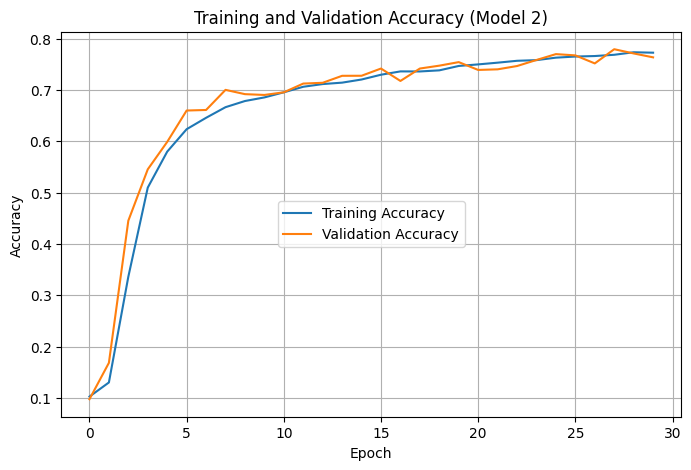

```python
# Plot the Training and Validation Accuracies for the second model

plt.figure(figsize=(8, 5))
plt.plot(history2.history['accuracy'], label='Training Accuracy')
plt.plot(history2.history['val_accuracy'], label='Validation Accuracy')
plt.title('Training and Validation Accuracy (Model 2)')
plt.xlabel('Epoch')
plt.ylabel('Accuracy')
plt.legend(loc='center')
plt.grid(True)
plt.show()
```

**Observations:**

- The plot shows that both training and validation accuracy increase rapidly during the initial epochs and then gradually plateau around 0.75–0.77. The training and validation curves are very close to each other, indicating that the model is not overfitting and generalizes well to unseen data. Compared to the previous, simpler model, this more complex architecture achieves higher accuracy, demonstrating improved learning capacity. However, the accuracy still does not reach very high values, suggesting that further improvements might require even more advanced architectures or additional data preprocessing.

## **Predictions on the test data**

- Make predictions on the test set using the second model.
- Print the obtained results using the classification report and the confusion matrix.
- Final observations on the obtained results.

**Note:** Earlier, we noticed that each entry of the target variable is a one-hot encoded vector but to print the classification report and confusion matrix, we must convert each entry of y_test to a single label.

```python
# Make predictions on the test set using the second model
from sklearn.metrics import classification_report, confusion_matrix

y_pred_probs = model2.predict(X_test_flat)
y_pred = np.argmax(y_pred_probs, axis=1)
y_true = np.argmax(y_test_encoded, axis=1)
```

```
563/563 ━━━━━━━━━━━━━━━━━━━━ 1s 2ms/step
```

### **Print the classification report and the confusion matrix for the test predictions. Write your observations on the final results.**

```python
# Print the classification report
print("Classification Report:\n", classification_report(y_true, y_pred))

# Print the confusion matrix
print("Confusion Matrix:\n", confusion_matrix(y_true, y_pred))
```

```
Classification Report:
               precision    recall  f1-score   support

           0       0.77      0.79      0.78      1814
           1       0.73      0.81      0.77      1828
           2       0.73      0.79      0.76      1803
           3       0.66      0.76      0.71      1719
           4       0.83      0.81      0.82      1812
           5       0.73      0.72      0.72      1768
           6       0.81      0.73      0.77      1832
           7       0.81      0.78      0.79      1808
           8       0.72      0.73      0.72      1812
           9       0.85      0.68      0.76      1804

    accuracy                           0.76     18000
   macro avg       0.76      0.76      0.76     18000
weighted avg       0.76      0.76      0.76     18000

Confusion Matrix:
 [[1428   68   35   48   32    8   66   24   71   34]
 [  31 1489   57   61   45   19   24   71   24    7]
 [  19   43 1430   90   27   28   12   95   31   28]
 [  25   61   77 1309   23  113   12   44   42   13]
 [  47   76   41   40 1463   32   46   19   27   21]
 [  38   40   29  164   19 1271   62   14   93   38]
 [ 100   36   24   33   71   62 1340   14  141   11]
 [  32   96  147   48   20   19   16 1402   15   13]
 [  54   53   62   80   33   88   64   14 1319   45]
 [  78   67   51   96   37  105   16   43   78 1233]]
```

## **Using Convolutional Neural Networks**

### **Load the dataset again and split the data into the train and the test dataset.**

```python
#load .h5 data
Data = h5py.File('/content/drive/MyDrive/Colab Notebooks/MIT_DATASETS/SVHN_single_grey1.h5', 'r')

#splite Data into training and testing dataset
X_train = Data['X_train'][:]
y_train = Data['y_train'][:]
X_test = Data['X_test'][:]
y_test = Data['y_test'][:]
```

Check the number of images in the training and the testing dataset.

```python
#print the length of training and testing datasets
print("Train shape:", X_train.shape, y_train.shape)
print("Test shape:", X_test.shape, y_test.shape)
```

```
Train shape: (42000, 32, 32) (42000,)
Test shape: (18000, 32, 32) (18000,)
```

## **Data preparation**

- Print the shape and the array of pixels for the first image in the training dataset.
- Reshape the train and the test dataset because we always have to give a 4D array as input to CNNs.
- Normalize the train and the test dataset by dividing by 255.
- Print the new shapes of the train and the test dataset.
- One-hot encode the target variable.

```python
# Print the shape and the array of pixels for the first image in the training dataset
print("Shape of the first image:", X_train[0].shape)
print("Pixel array of the first image:\n", X_train[0])
```

```
Shape of the first image: (32, 32)
Pixel array of the first image:
 [[ 33.0704  30.2601  26.852  ...  71.4471  58.2204  42.9939]
 [ 25.2283  25.5533  29.9765 ... 113.0209 103.3639  84.2949]
 [ 26.2775  22.6137  40.4763 ... 113.3028 121.775  115.4228]
 ...
 [ 28.5502  36.212   45.0801 ...  24.1359  25.0927  26.0603]
 [ 38.4352  26.4733  23.2717 ...  28.1094  29.4683  30.0661]
 [ 50.2984  26.0773  24.0389 ...  49.6682  50.853   53.0377]]
```

Reshape the dataset to be able to pass them to CNNs. Remember that we always have to give a 4D array as input to CNNs

```python
# Reshape the train and test datasets to 4D arrays for CNN input (samples, height, width, channels)
X_train_cnn = X_train.reshape(X_train.shape[0], 32, 32, 1)
X_test_cnn = X_test.reshape(X_test.shape[0], 32, 32, 1)

print("New shape of X_train for CNN:", X_train_cnn.shape)
print("New shape of X_test for CNN:", X_test_cnn.shape)
```

```
New shape of X_train for CNN: (42000, 32, 32, 1)
New shape of X_test for CNN: (18000, 32, 32, 1)
```

Normalize inputs from 0-255 to 0-1

```python
# Normalize inputs from 0-255 to 0-1 for CNNs
X_train = X_train / 255.0
X_test = X_test / 255.0

print("Min/Max of X_train:", X_train.min(), X_train.max())
print("Min/Max of X_test:", X_test.min(), X_test.max())
```

```
Min/Max of X_train: 0.0 0.9999
Min/Max of X_test: 0.0 0.9999
```

Print New shape of Training and Test

```python
# Print new shape of Training and Test data
print("New shape of X_train:", X_train.shape, y_train.shape)
print("New shape of X_test:", X_test.shape, y_test.shape)
```

```
New shape of X_train: (42000, 32, 32) (42000,)
New shape of X_test: (18000, 32, 32) (18000,)
```

### **One-hot encode the labels in the target variable y_train and y_test.**

```python
# One-hot encode the target variable for CNN input
y_train_encoded = to_categorical(y_train, num_classes=10)
y_test_encoded = to_categorical(y_test, num_classes=10)

print("One-hot encoded y_train (first 10 labels):\n", y_train_encoded[:10])
print("One-hot encoded y_test (first 10 labels):\n", y_test_encoded[:10])
```

```
One-hot encoded y_train (first 10 labels):
 [[0. 0. 1. 0. 0. 0. 0. 0. 0. 0.]
 [0. 0. 0. 0. 0. 0. 1. 0. 0. 0.]
 [0. 0. 0. 0. 0. 0. 0. 1. 0. 0.]
 [0. 0. 0. 0. 1. 0. 0. 0. 0. 0.]
 [0. 0. 0. 0. 1. 0. 0. 0. 0. 0.]
 [1. 0. 0. 0. 0. 0. 0. 0. 0. 0.]
 [0. 0. 0. 1. 0. 0. 0. 0. 0. 0.]
 [1. 0. 0. 0. 0. 0. 0. 0. 0. 0.]
 [0. 0. 0. 0. 0. 0. 0. 1. 0. 0.]
 [0. 0. 0. 1. 0. 0. 0. 0. 0. 0.]]
One-hot encoded y_test (first 10 labels):
 [[0. 1. 0. 0. 0. 0. 0. 0. 0. 0.]
 [0. 0. 0. 0. 0. 0. 0. 1. 0. 0.]
 [0. 0. 1. 0. 0. 0. 0. 0. 0. 0.]
 [0. 0. 0. 0. 0. 0. 0. 0. 0. 1.]
 [1. 0. 0. 0. 0. 0. 0. 0. 0. 0.]
 [0. 0. 0. 0. 0. 0. 0. 0. 0. 1.]
 [0. 1. 0. 0. 0. 0. 0. 0. 0. 0.]
 [0. 0. 0. 0. 0. 0. 0. 0. 1. 0.]
 [0. 0. 0. 0. 1. 0. 0. 0. 0. 0.]
 [0. 0. 0. 0. 1. 0. 0. 0. 0. 0.]]
```

## **Model Building**

Now that we have done data preprocessing, let's build a CNN model. Fix the seed for random number generators

```python
# Fix the seed for random number generators to ensure reproducibility
import random
seed_value = 42
np.random.seed(seed_value)
tf.random.set_seed(seed_value)
random.seed(seed_value)
```

### **Model Architecture**

- **Write a function** that returns a sequential model with the following architecture:
- First Convolutional layer with **16 filters and the kernel size of 3x3**. Use the **'same' padding** and provide the **input shape = (32, 32, 1)**
- Add a **LeakyRelu layer** with the **slope equal to 0.1**
- Second Convolutional layer with **32 filters and the kernel size of 3x3 with 'same' padding**
- Another **LeakyRelu** with the **slope equal to 0.1**
- A **max-pooling layer** with a **pool size of 2x2**
- **Flatten** the output from the previous layer
- Add a **dense layer with 32 nodes**
- Add a **LeakyRelu layer with the slope equal to 0.1**
- Add the final **output layer with nodes equal to the number of classes, i.e., 10** and **'softmax' as the activation function**
- Compile the model with the **loss equal to categorical_crossentropy, optimizer equal to Adam(learning_rate = 0.001), and metric equal to 'accuracy'**. Do not fit the model here, just return the compiled model.
- Call the function cnn_model_1 and store the output in a new variable.
- Print the summary of the model.
- Fit the model on the training data with a **validation split of 0.2, batch size = 32, verbose = 1, and epochs = 20**. Store the model building history to use later for visualization.

### **Build and train a CNN model as per the above mentioned architecture.**

```python
from tensorflow.keras.layers import Conv2D, Dense, Flatten, MaxPooling2D, LeakyReLU
# Function to build the CNN model
def cnn_model_1():
    model = Sequential()
    model.add(Conv2D(16, (3, 3), padding='same', input_shape=(32, 32, 1)))
    model.add(LeakyReLU(alpha=0.1))
    model.add(Conv2D(32, (3, 3), padding='same'))
    model.add(LeakyReLU(alpha=0.1))
    model.add(MaxPooling2D(pool_size=(2, 2)))
    model.add(Flatten())
    model.add(Dense(32))
    model.add(LeakyReLU(alpha=0.1))
    model.add(Dense(10, activation='softmax'))
    model.compile(
        loss='categorical_crossentropy',
        optimizer=Adam(learning_rate=0.001),
        metrics=['accuracy']
    )
    return model

# Build and summarize the model
cnn1 = cnn_model_1()
cnn1.summary()

# Fit the model
history_cnn1 = cnn1.fit(
    X_train_cnn, y_train_encoded,
    validation_split=0.2,
    batch_size=32,
    epochs=20,
    verbose=1
)
```

```
Model: "sequential"
```

```
┏━━━━━━━━━━━━━━━━━━━━━━━━━━━━━━━━━┳━━━━━━━━━━━━━━━━━━━━━━━━┳━━━━━━━━━━━━━━━┓
┃ Layer (type)                    ┃ Output Shape           ┃       Param # ┃
┡━━━━━━━━━━━━━━━━━━━━━━━━━━━━━━━━━╇━━━━━━━━━━━━━━━━━━━━━━━━╇━━━━━━━━━━━━━━━┩
│ conv2d (Conv2D)                 │ (None, 32, 32, 16)     │           160 │
├─────────────────────────────────┼────────────────────────┼───────────────┤
│ leaky_re_lu (LeakyReLU)         │ (None, 32, 32, 16)     │             0 │
├─────────────────────────────────┼────────────────────────┼───────────────┤
│ conv2d_1 (Conv2D)               │ (None, 32, 32, 32)     │         4,640 │
├─────────────────────────────────┼────────────────────────┼───────────────┤
│ leaky_re_lu_1 (LeakyReLU)       │ (None, 32, 32, 32)     │             0 │
├─────────────────────────────────┼────────────────────────┼───────────────┤
│ max_pooling2d (MaxPooling2D)    │ (None, 16, 16, 32)     │             0 │
├─────────────────────────────────┼────────────────────────┼───────────────┤
│ flatten (Flatten)               │ (None, 8192)           │             0 │
├─────────────────────────────────┼────────────────────────┼───────────────┤
│ dense (Dense)                   │ (None, 32)             │       262,176 │
├─────────────────────────────────┼────────────────────────┼───────────────┤
│ leaky_re_lu_2 (LeakyReLU)       │ (None, 32)             │             0 │
├─────────────────────────────────┼────────────────────────┼───────────────┤
│ dense_1 (Dense)                 │ (None, 10)             │           330 │
└─────────────────────────────────┴────────────────────────┴───────────────┘
```

```
 Total params: 267,306 (1.02 MB)
```

```
 Trainable params: 267,306 (1.02 MB)
```

```
 Non-trainable params: 0 (0.00 B)
```

```
1050/1050 ━━━━━━━━━━━━━━━━━━━━ 49s 46ms/step - accuracy: 0.3421 - loss: 6.1110 - val_accuracy: 0.7698 - val_loss: 0.8243
1050/1050 ━━━━━━━━━━━━━━━━━━━━ 46s 44ms/step - accuracy: 0.7707 - loss: 0.7857 - val_accuracy: 0.8017 - val_loss: 0.7086
1050/1050 ━━━━━━━━━━━━━━━━━━━━ 46s 44ms/step - accuracy: 0.8224 - loss: 0.6071 - val_accuracy: 0.8154 - val_loss: 0.6571
1050/1050 ━━━━━━━━━━━━━━━━━━━━ 46s 43ms/step - accuracy: 0.8450 - loss: 0.5293 - val_accuracy: 0.8362 - val_loss: 0.6143
1050/1050 ━━━━━━━━━━━━━━━━━━━━ 46s 44ms/step - accuracy: 0.8576 - loss: 0.4814 - val_accuracy: 0.8319 - val_loss: 0.6336
1050/1050 ━━━━━━━━━━━━━━━━━━━━ 46s 43ms/step - accuracy: 0.8694 - loss: 0.4423 - val_accuracy: 0.8426 - val_loss: 0.6320
1050/1050 ━━━━━━━━━━━━━━━━━━━━ 46s 44ms/step - accuracy: 0.8753 - loss: 0.4109 - val_accuracy: 0.8321 - val_loss: 0.7119
1050/1050 ━━━━━━━━━━━━━━━━━━━━ 46s 44ms/step - accuracy: 0.8857 - loss: 0.3789 - val_accuracy: 0.8250 - val_loss: 0.7971
1050/1050 ━━━━━━━━━━━━━━━━━━━━ 49s 46ms/step - accuracy: 0.8938 - loss: 0.3530 - val_accuracy: 0.8419 - val_loss: 0.7383
1050/1050 ━━━━━━━━━━━━━━━━━━━━ 46s 44ms/step - accuracy: 0.9061 - loss: 0.3254 - val_accuracy: 0.8501 - val_loss: 0.7553
1050/1050 ━━━━━━━━━━━━━━━━━━━━ 46s 44ms/step - accuracy: 0.9050 - loss: 0.3107 - val_accuracy: 0.8483 - val_loss: 0.7426
1050/1050 ━━━━━━━━━━━━━━━━━━━━ 47s 44ms/step - accuracy: 0.9053 - loss: 0.3048 - val_accuracy: 0.8500 - val_loss: 0.7434
1050/1050 ━━━━━━━━━━━━━━━━━━━━ 46s 44ms/step - accuracy: 0.9200 - loss: 0.2625 - val_accuracy: 0.8374 - val_loss: 0.7976
1050/1050 ━━━━━━━━━━━━━━━━━━━━ 46s 44ms/step - accuracy: 0.9187 - loss: 0.2608 - val_accuracy: 0.8401 - val_loss: 0.8609
1050/1050 ━━━━━━━━━━━━━━━━━━━━ 46s 44ms/step - accuracy: 0.9236 - loss: 0.2536 - val_accuracy: 0.8429 - val_loss: 0.9095
1050/1050 ━━━━━━━━━━━━━━━━━━━━ 46s 44ms/step - accuracy: 0.9240 - loss: 0.2339 - val_accuracy: 0.8468 - val_loss: 0.8319
1050/1050 ━━━━━━━━━━━━━━━━━━━━ 46s 44ms/step - accuracy: 0.9333 - loss: 0.2144 - val_accuracy: 0.8495 - val_loss: 0.9242
1050/1050 ━━━━━━━━━━━━━━━━━━━━ 47s 44ms/step - accuracy: 0.9382 - loss: 0.1947 - val_accuracy: 0.8440 - val_loss: 0.9511
1050/1050 ━━━━━━━━━━━━━━━━━━━━ 46s 44ms/step - accuracy: 0.9313 - loss: 0.2134 - val_accuracy: 0.8375 - val_loss: 0.9912
1050/1050 ━━━━━━━━━━━━━━━━━━━━ 46s 44ms/step - accuracy: 0.9399 - loss: 0.1865 - val_accuracy: 0.8450 - val_loss: 0.9095
```

### **Plot the Training and Validation Accuracies and Write your observations.**

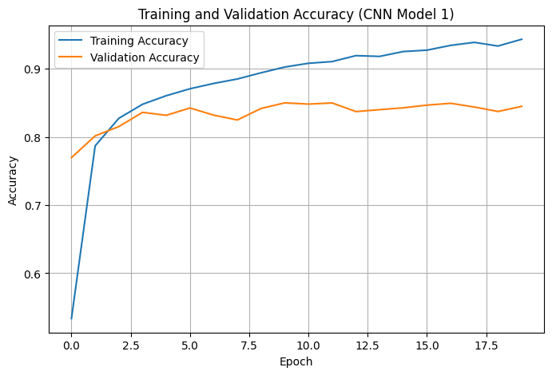

```python
# Plot the Training and Validation Accuracies for the CNN model

plt.figure(figsize=(8, 5))
plt.plot(history_cnn1.history['accuracy'], label='Training Accuracy')
plt.plot(history_cnn1.history['val_accuracy'], label='Validation Accuracy')
plt.title('Training and Validation Accuracy (CNN Model 1)')
plt.xlabel('Epoch')
plt.ylabel('Accuracy')
plt.legend(loc='upper left')
plt.grid(True)
plt.show()
```

**Observations:**

Let's build another model and see if we can get a better model with generalized performance.

First, we need to clear the previous model's history from the Keras backend. Also, let's fix the seed again after clearing the backend.

```python
# Clear previous model's history and backend
from tensorflow.keras import backend as K
K.clear_session()

# Fix the seed for reproducibility
seed_value = 42
np.random.seed(seed_value)
tf.random.set_seed(seed_value)
random.seed(seed_value)
```

### **Second Model Architecture**

- Write a function that returns a sequential model with the following architecture:
- First Convolutional layer with **16 filters and the kernel size of 3x3**. Use the **'same' padding** and provide the **input shape = (32, 32, 1)**
- Add a **LeakyRelu layer** with the **slope equal to 0.1**
- Second Convolutional layer with **32 filters and the kernel size of 3x3 with 'same' padding**
- Add **LeakyRelu** with the **slope equal to 0.1**
- Add a **max-pooling layer** with a **pool size of 2x2**
- Add a **BatchNormalization layer**
- Third Convolutional layer with **32 filters and the kernel size of 3x3 with 'same' padding**
- Add a **LeakyRelu layer with the slope equal to 0.1**
- Fourth Convolutional layer **64 filters and the kernel size of 3x3 with 'same' padding**
- Add a **LeakyRelu layer with the slope equal to 0.1**
- Add a **max-pooling layer** with a **pool size of 2x2**
- Add a **BatchNormalization layer**
- **Flatten** the output from the previous layer
- Add a **dense layer with 32 nodes**
- Add a **LeakyRelu layer with the slope equal to 0.1**
- Add a **dropout layer with the rate equal to 0.5**
- Add the final **output layer with nodes equal to the number of classes, i.e., 10** and **'softmax' as the activation function**
- Compile the model with the **categorical_crossentropy loss, adam optimizers (learning_rate = 0.001), and metric equal to 'accuracy'**. Do not fit the model here, just return the compiled model.
- Call the function cnn_model_2 and store the model in a new variable.
- Print the summary of the model.
- Fit the model on the train data with a **validation split of 0.2, batch size = 128, verbose = 1, and epochs = 30**. Store the model building history to use later for visualization.

### **Build and train the second CNN model as per the above mentioned architecture.**

```python
#Define the model function
def cnn_model_2():
    model = Sequential()
    # First Conv layer
    model.add(Conv2D(16, (3, 3), padding='same', input_shape=(32, 32, 1)))
    model.add(LeakyReLU(alpha=0.1))
    # Second Conv layer
    model.add(Conv2D(32, (3, 3), padding='same'))
    model.add(LeakyReLU(alpha=0.1))
    model.add(MaxPooling2D(pool_size=(2, 2)))
    model.add(BatchNormalization())
    # Third Conv layer
    model.add(Conv2D(32, (3, 3), padding='same'))
    model.add(LeakyReLU(alpha=0.1))
    # Fourth Conv layer
    model.add(Conv2D(64, (3, 3), padding='same'))
    model.add(LeakyReLU(alpha=0.1))
    model.add(MaxPooling2D(pool_size=(2, 2)))
    model.add(BatchNormalization())
    # Flatten and Dense layers
    model.add(Flatten())
    model.add(Dense(32))
    model.add(LeakyReLU(alpha=0.1))
    model.add(Dropout(0.5))
    # Output layer
    model.add(Dense(10, activation='softmax'))
    # Compile
    model.compile(
        loss='categorical_crossentropy',
        optimizer=Adam(learning_rate=0.001),
        metrics=['accuracy']
    )
    return model

# Build and summarize the model
cnn2 = cnn_model_2()
cnn2.summary()

# Fit the model
history_cnn2 = cnn2.fit(
    X_train_cnn, y_train_encoded,
    validation_split=0.2,
    batch_size=128,
    epochs=30,
    verbose=1
)
```

```
Model: "sequential"
```

```
┏━━━━━━━━━━━━━━━━━━━━━━━━━━━━━━━━━┳━━━━━━━━━━━━━━━━━━━━━━━━┳━━━━━━━━━━━━━━━┓
┃ Layer (type)                    ┃ Output Shape           ┃       Param # ┃
┡━━━━━━━━━━━━━━━━━━━━━━━━━━━━━━━━━╇━━━━━━━━━━━━━━━━━━━━━━━━╇━━━━━━━━━━━━━━━┩
│ conv2d (Conv2D)                 │ (None, 32, 32, 16)     │           160 │
├─────────────────────────────────┼────────────────────────┼───────────────┤
│ leaky_re_lu (LeakyReLU)         │ (None, 32, 32, 16)     │             0 │
├─────────────────────────────────┼────────────────────────┼───────────────┤
│ conv2d_1 (Conv2D)               │ (None, 32, 32, 32)     │         4,640 │
├─────────────────────────────────┼────────────────────────┼───────────────┤
│ leaky_re_lu_1 (LeakyReLU)       │ (None, 32, 32, 32)     │             0 │
├─────────────────────────────────┼────────────────────────┼───────────────┤
│ max_pooling2d (MaxPooling2D)    │ (None, 16, 16, 32)     │             0 │
├─────────────────────────────────┼────────────────────────┼───────────────┤
│ batch_normalization             │ (None, 16, 16, 32)     │           128 │
│ (BatchNormalization)            │                        │               │
├─────────────────────────────────┼────────────────────────┼───────────────┤
│ conv2d_2 (Conv2D)               │ (None, 16, 16, 32)     │         9,248 │
├─────────────────────────────────┼────────────────────────┼───────────────┤
│ leaky_re_lu_2 (LeakyReLU)       │ (None, 16, 16, 32)     │             0 │
├─────────────────────────────────┼────────────────────────┼───────────────┤
│ conv2d_3 (Conv2D)               │ (None, 16, 16, 64)     │        18,496 │
├─────────────────────────────────┼────────────────────────┼───────────────┤
│ leaky_re_lu_3 (LeakyReLU)       │ (None, 16, 16, 64)     │             0 │
├─────────────────────────────────┼────────────────────────┼───────────────┤
│ max_pooling2d_1 (MaxPooling2D)  │ (None, 8, 8, 64)       │             0 │
├─────────────────────────────────┼────────────────────────┼───────────────┤
│ batch_normalization_1           │ (None, 8, 8, 64)       │           256 │
│ (BatchNormalization)            │                        │               │
├─────────────────────────────────┼────────────────────────┼───────────────┤
│ flatten (Flatten)               │ (None, 4096)           │             0 │
├─────────────────────────────────┼────────────────────────┼───────────────┤
│ dense (Dense)                   │ (None, 32)             │       131,104 │
├─────────────────────────────────┼────────────────────────┼───────────────┤
│ leaky_re_lu_4 (LeakyReLU)       │ (None, 32)             │             0 │
├─────────────────────────────────┼────────────────────────┼───────────────┤
│ dropout (Dropout)               │ (None, 32)             │             0 │
├─────────────────────────────────┼────────────────────────┼───────────────┤
│ dense_1 (Dense)                 │ (None, 10)             │           330 │
└─────────────────────────────────┴────────────────────────┴───────────────┘
```

```
 Total params: 164,362 (642.04 KB)
```

```
 Trainable params: 164,170 (641.29 KB)
```

```
 Non-trainable params: 192 (768.00 B)
```

```
263/263 ━━━━━━━━━━━━━━━━━━━━ 102s 378ms/step - accuracy: 0.3368 - loss: 1.9104 - val_accuracy: 0.8131 - val_loss: 0.6612
263/263 ━━━━━━━━━━━━━━━━━━━━ 98s 371ms/step - accuracy: 0.7863 - loss: 0.7003 - val_accuracy: 0.8723 - val_loss: 0.4507
263/263 ━━━━━━━━━━━━━━━━━━━━ 101s 384ms/step - accuracy: 0.8278 - loss: 0.5709 - val_accuracy: 0.8789 - val_loss: 0.4262
263/263 ━━━━━━━━━━━━━━━━━━━━ 104s 395ms/step - accuracy: 0.8479 - loss: 0.5086 - val_accuracy: 0.8794 - val_loss: 0.4384
263/263 ━━━━━━━━━━━━━━━━━━━━ 102s 388ms/step - accuracy: 0.8599 - loss: 0.4689 - val_accuracy: 0.8900 - val_loss: 0.3869
263/263 ━━━━━━━━━━━━━━━━━━━━ 103s 391ms/step - accuracy: 0.8711 - loss: 0.4213 - val_accuracy: 0.8965 - val_loss: 0.3787
263/263 ━━━━━━━━━━━━━━━━━━━━ 102s 390ms/step - accuracy: 0.8788 - loss: 0.3992 - val_accuracy: 0.8987 - val_loss: 0.3709
263/263 ━━━━━━━━━━━━━━━━━━━━ 102s 389ms/step - accuracy: 0.8916 - loss: 0.3645 - val_accuracy: 0.8996 - val_loss: 0.3622
263/263 ━━━━━━━━━━━━━━━━━━━━ 103s 393ms/step - accuracy: 0.8946 - loss: 0.3489 - val_accuracy: 0.9012 - val_loss: 0.3654
263/263 ━━━━━━━━━━━━━━━━━━━━ 99s 377ms/step - accuracy: 0.8980 - loss: 0.3310 - val_accuracy: 0.9048 - val_loss: 0.3552
263/263 ━━━━━━━━━━━━━━━━━━━━ 101s 383ms/step - accuracy: 0.9034 - loss: 0.3098 - val_accuracy: 0.9100 - val_loss: 0.3409
263/263 ━━━━━━━━━━━━━━━━━━━━ 102s 386ms/step - accuracy: 0.9076 - loss: 0.2951 - val_accuracy: 0.9005 - val_loss: 0.3701
263/263 ━━━━━━━━━━━━━━━━━━━━ 101s 382ms/step - accuracy: 0.9098 - loss: 0.2859 - val_accuracy: 0.9083 - val_loss: 0.3590
263/263 ━━━━━━━━━━━━━━━━━━━━ 99s 375ms/step - accuracy: 0.9150 - loss: 0.2709 - val_accuracy: 0.9127 - val_loss: 0.3705
263/263 ━━━━━━━━━━━━━━━━━━━━ 101s 386ms/step - accuracy: 0.9195 - loss: 0.2570 - val_accuracy: 0.9104 - val_loss: 0.3657
263/263 ━━━━━━━━━━━━━━━━━━━━ 99s 378ms/step - accuracy: 0.9238 - loss: 0.2434 - val_accuracy: 0.9051 - val_loss: 0.4023
263/263 ━━━━━━━━━━━━━━━━━━━━ 101s 386ms/step - accuracy: 0.9207 - loss: 0.2438 - val_accuracy: 0.9099 - val_loss: 0.3885
263/263 ━━━━━━━━━━━━━━━━━━━━ 98s 371ms/step - accuracy: 0.9261 - loss: 0.2255 - val_accuracy: 0.9038 - val_loss: 0.4077
263/263 ━━━━━━━━━━━━━━━━━━━━ 100s 382ms/step - accuracy: 0.9314 - loss: 0.2185 - val_accuracy: 0.8996 - val_loss: 0.4409
263/263 ━━━━━━━━━━━━━━━━━━━━ 99s 375ms/step - accuracy: 0.9283 - loss: 0.2172 - val_accuracy: 0.9086 - val_loss: 0.3951
263/263 ━━━━━━━━━━━━━━━━━━━━ 99s 375ms/step - accuracy: 0.9287 - loss: 0.2190 - val_accuracy: 0.9067 - val_loss: 0.4597
263/263 ━━━━━━━━━━━━━━━━━━━━ 100s 381ms/step - accuracy: 0.9382 - loss: 0.1925 - val_accuracy: 0.9144 - val_loss: 0.3972
263/263 ━━━━━━━━━━━━━━━━━━━━ 102s 390ms/step - accuracy: 0.9375 - loss: 0.1936 - val_accuracy: 0.9099 - val_loss: 0.4216
263/263 ━━━━━━━━━━━━━━━━━━━━ 104s 396ms/step - accuracy: 0.9352 - loss: 0.1939 - val_accuracy: 0.9040 - val_loss: 0.4357
263/263 ━━━━━━━━━━━━━━━━━━━━ 98s 373ms/step - accuracy: 0.9418 - loss: 0.1793 - val_accuracy: 0.9108 - val_loss: 0.4198
263/263 ━━━━━━━━━━━━━━━━━━━━ 103s 394ms/step - accuracy: 0.9426 - loss: 0.1741 - val_accuracy: 0.9132 - val_loss: 0.4387
263/263 ━━━━━━━━━━━━━━━━━━━━ 103s 391ms/step - accuracy: 0.9423 - loss: 0.1713 - val_accuracy: 0.9105 - val_loss: 0.4462
263/263 ━━━━━━━━━━━━━━━━━━━━ 101s 385ms/step - accuracy: 0.9462 - loss: 0.1650 - val_accuracy: 0.9054 - val_loss: 0.4370
263/263 ━━━━━━━━━━━━━━━━━━━━ 99s 375ms/step - accuracy: 0.9449 - loss: 0.1663 - val_accuracy: 0.9114 - val_loss: 0.4522
263/263 ━━━━━━━━━━━━━━━━━━━━ 101s 382ms/step - accuracy: 0.9468 - loss: 0.1584 - val_accuracy: 0.9133 - val_loss: 0.4824
```

### **Plot the Training and Validation accuracies and write your observations.**

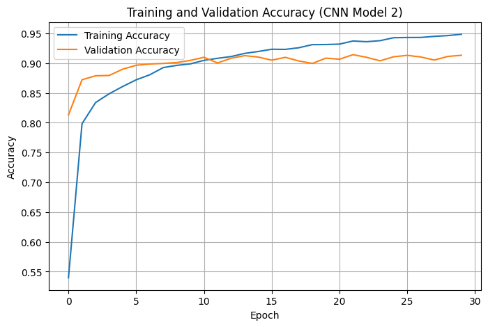

```python
# Plot Training and Validation Accuracies
plt.figure(figsize=(8, 5))
plt.plot(history_cnn2.history['accuracy'], label='Training Accuracy')
plt.plot(history_cnn2.history['val_accuracy'], label='Validation Accuracy')
plt.title('Training and Validation Accuracy (CNN Model 2)')
plt.xlabel('Epoch')
plt.ylabel('Accuracy')
plt.legend(loc='upper left')
plt.grid(True)
plt.show()
```

**Observations:**

- Both training and validation accuracies increase rapidly during the initial epochs, indicating effective learning. The training accuracy continues to improve and reaches about 0.95 by the end of training.
- The validation accuracy also improves and stabilizes around 0.91, which is higher and more stable compared to the previous model.
- The gap between training and validation accuracy is relatively small, suggesting reduced overfitting and better generalization.
- The validation accuracy curve is stable with minor fluctuations, indicating consistent performance on unseen data.
- Overall, the model demonstrates strong and generalized performance, likely due to the use of BatchNormalization and Dropout layers.

## **Predictions on the test data**

- Make predictions on the test set using the second model.
- Print the obtained results using the classification report and the confusion matrix.
- Final observations on the obtained results.

### **Make predictions on the test data using the second model.**

```python
# Make predictions on the test data using the second model
y_pred_probs = cnn2.predict(X_test_cnn)
y_pred_classes = np.argmax(y_pred_probs, axis=1)
```

```
563/563 ━━━━━━━━━━━━━━━━━━━━ 9s 17ms/step
```

**Note:** Earlier, we noticed that each entry of the target variable is a one-hot encoded vector, but to print the classification report and confusion matrix, we must convert each entry of y_test to a single label.

```python
from sklearn.metrics import classification_report, confusion_matrix

# Convert one-hot encoded y_test to single label
y_test_labels = np.argmax(y_test_encoded, axis=1)
```

### **Write your final observations on the performance of the model on the test data.**

```python
# Print classification report
print("Classification Report:")
print(classification_report(y_test_labels, y_pred_classes))

# Print confusion matrix
print("Confusion Matrix:")
print(confusion_matrix(y_test_labels, y_pred_classes))
```

```
Classification Report:
              precision    recall  f1-score   support

           0       0.92      0.94      0.93      1814
           1       0.84      0.93      0.89      1828
           2       0.93      0.92      0.93      1803
           3       0.91      0.88      0.89      1719
           4       0.92      0.93      0.92      1812
           5       0.91      0.92      0.92      1768
           6       0.89      0.91      0.90      1832
           7       0.95      0.90      0.93      1808
           8       0.91      0.89      0.90      1812
           9       0.94      0.89      0.91      1804

    accuracy                           0.91     18000
   macro avg       0.91      0.91      0.91     18000
weighted avg       0.91      0.91      0.91     18000

Confusion Matrix:
[[1705   27    6    4   12    1   25    7    7   20]
 [  20 1708    8   10   41    3    7   20    9    2]
 [  12   25 1662   15   20    4    5   22   17   21]
 [   6   35   23 1506   15   60   22    7   36    9]
 [   7   53   16    6 1682    5   17    4    9   13]
 [   0   11    7   38    9 1628   48    0   17   10]
 [  25   12   10   14   17   36 1673    2   38    5]
 [  16  105   21   13    9    4    4 1624    6    6]
 [  26   23    9   30    7   15   64    3 1616   19]
 [  38   28   21   19   18   24   14   12   24 1606]]
```

**Final Observations:**

**Model Selection, Business insights and Recommendations**

- Based on the training history and classification reports, CNN Model 2 (cnn_model_2) achieves the highest accuracy and best generalization on the SVHN dataset.
- CNN Model 2 provides the best performance for recognizing street view house numbers, with high accuracy on both training and test data.
- The model is robust to variations in digit style and background, making it suitable for real-world deployment.
- Misclassifications are mainly due to poor image quality, occlusions, or ambiguous digits, which can be further reduced with more data or advanced augmentation.

**Recommendations**

- Deploy CNN Model 2 in production for automated address digitization from street view images, improving efficiency for logistics, mapping, and delivery services.
- Integrate a confidence threshold to flag uncertain predictions for manual review, ensuring high data quality.
- Periodically retrain the model with new data to adapt to changing street environments and signage styles.
- Consider further improvements with data augmentation, ensemble methods, or more advanced CNN architectures for even higher accuracy.